# Impact of RNA-seq count normalization on clustering of co-expressed genes

Layla Saad Montoya and Florent Chuffart

2022-04-08

# 1 Introduction

The goal of this study is to first identify then quantify the differences between normalization methods and their subsequent gene clustering. We wish to highlight the mathematical basis for these differences as well as the ways in which these methods affect the raw results.

# 2 Data

## 2.1 Dataset

The dataset raw_counts is obtained from the NTTCGA group of TCGA database. TCGA (The Cancer Genome Atlas) is a worldwide database containing sequenced cell and tissue samples, and their respective genomic, epigenomic, transcriptomic, and proteomic data. Clincal data as well as survival data and follow-up are equally available. Our data consists of healthy, non-tumorous tissue samples, to be used as a positive control to the LIHC study (see `study_01_lihc_cpsf3`).

```r
load("data/nttcga_raw_counts.RData")
raw_counts = nttcga_raw_counts
head(raw_counts[,1:4])
```

```
#>           TCGA-KO-8403-KI TCGA-KN-8429-KI TCGA-KN-8431-KI TCGA-KN-8432-KI
#> DDX11L1                 0               0               0               0
#> WASH7P                 59              49              63              57
#> MIR6859-1               0               0               0               0
#> FAM138A                 0               0               0               0
#> OR4F5                   0               0               0               0
#> MIR6859-2               1               0               0               0
```

```r
dim(raw_counts)
```

```
#> [1] 25360   296
```

### 2.1.1 Geneset

Our raw data set, containing 25360 genes, will be reduced to a gene set containing 117 tissue-specific genes belonging to lung, kidney, liver, prostate tissue. This will allow us to confirm the correlation between tissue samples and expressed genes and verify that clustering is consistent.

```r
features = c(
  CHIAP2       = "lung",
  CHIA         = "lung",
  LOC101927884 = "lung",
  SNTN         = "lung",
  LINC02016    = "lung",
  HTR3C        = "lung",
  CSF2         = "lung",
  ROS1         = "lung",
  RPL13AP17    = "lung",
  DCSTAMP      = "lung",
  MS4A15       = "lung",
  LINC00551    = "lung",
  FAM92B       = "lung",
  LOC101928418 = "lung",
  PARAL1       = "lung",
  CT45A10      = "lung",
  CLDN19       = "kidney",
  LINC01788    = "kidney",
  LINC01762    = "kidney",
  ATP6V1G3     = "kidney",
  OR2T10       = "kidney",
  LINC01158    = "kidney",
  SLC22A13     = "kidney",
  TMEM207      = "kidney",
  LOC100506444 = "kidney",
  AFP          = "kidney",
  SLC6A18      = "kidney",
  LINC02149    = "kidney",
  CDH9         = "kidney",
  TMEM174      = "kidney",
  SLC4A9       = "kidney",
  SLC34A1      = "kidney",
  PFN3         = "kidney",
  MCCD1        = "kidney",
  SLC22A2      = "kidney",
  LINC01510    = "kidney",
  SLC7A13      = "kidney",
  LINC01230    = "kidney",
  LINC00845    = "kidney",
  HMX2         = "kidney",
  SLC22A24     = "kidney",
  SLC22A11     = "kidney",
  SLC22A12     = "kidney",
  KCNJ1        = "kidney",
  LINC00379    = "kidney",
  LINC02294    = "kidney",
  LINC00645    = "kidney",
  YWHAEP7      = "kidney",
  RDH8         = "kidney",
  SMIM34B      = "kidney",
  DNMT3L       = "kidney",
  PLAC1        = "kidney",
  PRAMEF10     = "liver",
  PRAMEF33     = "liver",
  C8A          = "liver",
  NBPF13P      = "liver",
  CFHR4        = "liver",
  CFHR2        = "liver",
  CFHR5        = "liver",
  F13B         = "liver",
  BMP10        = "liver",
  SPP2         = "liver",
  UROC1        = "liver",
  LOC100507389 = "liver",
  LINC02037    = "liver",
  LINC02428    = "liver",
  LINC02159    = "liver",
  SLC17A2      = "liver",
  SLC22A1      = "liver",
  LOC157273    = "liver",
  CYP7A1       = "liver",
  AKR1C6P      = "liver",
  GDF2         = "liver",
  MBL2         = "liver",
  F2           = "liver",
  SLC22A25     = "liver",
  SLC22A10     = "liver",
  SLC22A9      = "liver",
  LOC101929427 = "liver",
  SLCO1B1      = "liver",
  INHBE        = "liver",
  SERPINA10    = "liver",
  SERPINA2     = "liver",
  CYP1A2       = "liver",
  NPW          = "liver",
  MT1B         = "liver",
  CA5A         = "liver",
  LOC101927571 = "liver",
  C3P1         = "liver",
  CYP2A7       = "liver",
  CYP2A13      = "liver",
  APOC4        = "liver",
  FGF21        = "liver",
  HAO1         = "liver",
  LINC01370    = "liver",
  SERPINA7     = "liver",
  F9           = "liver",
  TTTY2B       = "liver",
  TTTY2        = "liver",
  CYP4F62P     = "prostate",
  CYP4F30P     = "prostate",
  LOC440910    = "prostate",
  PCGEM1       = "prostate",
  SOX14        = "prostate",
  PCAT4        = "prostate",
  SP8          = "prostate",
  RLN1         = "prostate",
  PCA3         = "prostate",
  LOC283194    = "prostate",
  LINC02297    = "prostate",
  LOC100508046 = "prostate",
  LOC101929572 = "prostate",
  OACYLP       = "prostate",
  CYP4F8       = "prostate",
  SEMG1        = "prostate",
  LINC00314    = "prostate",
  LINC00161    = "prostate"
)
idx_features = names(features)
```

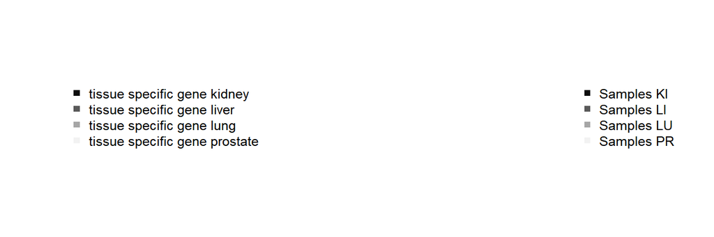

# 3 RPM

Reads Per Million (RPM) is a transcript expression unit. To calculate RPM the formula consists of dividing the number of raw counts by the total number of reads (or library size) and multiplying by a 1 million factor. This method is commonly used for inter-sample comparisons and as a basic unit of gene expression. This method does not center counts around zero.

## 3.1 Scaling factors

```r
rpm_sf = colSums(raw_counts)/10^6
rpm = t(t(raw_counts)/rpm_sf)
```

## 3.2 Heatmap

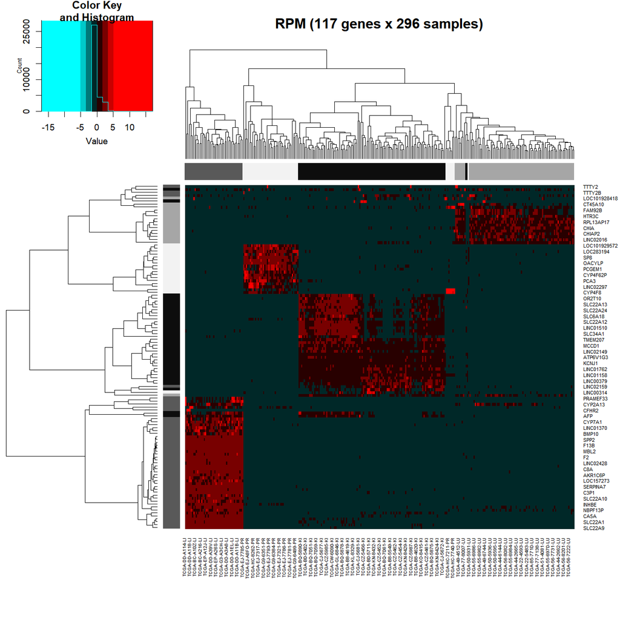

# 4 DESeq2

DESeq2 is a standard normalization method used for differential expression analysis. It is based on the RLE method (Relative Log Expression) and accounts for biases such as sequencing depth, library composition and PCR affinity / RNA composition. DESeq2 is the main normalization method used in Differential Expression Analysis at the IAB.

## 4.1 Scaling factors

```r
colData = data.frame(id=colnames(raw_counts))
dds = DESeq2::DESeqDataSetFromMatrix(countData=raw_counts, colData=colData, design= ~ 1)
dds = DESeq2::estimateSizeFactors(dds)
deseq2_sf = dds$sizeFactor
deseq2 = t(t(raw_counts)/deseq2_sf)
deseq2 = DESeq2::counts(dds, normalized=TRUE)
```

## 4.2 Heatmap

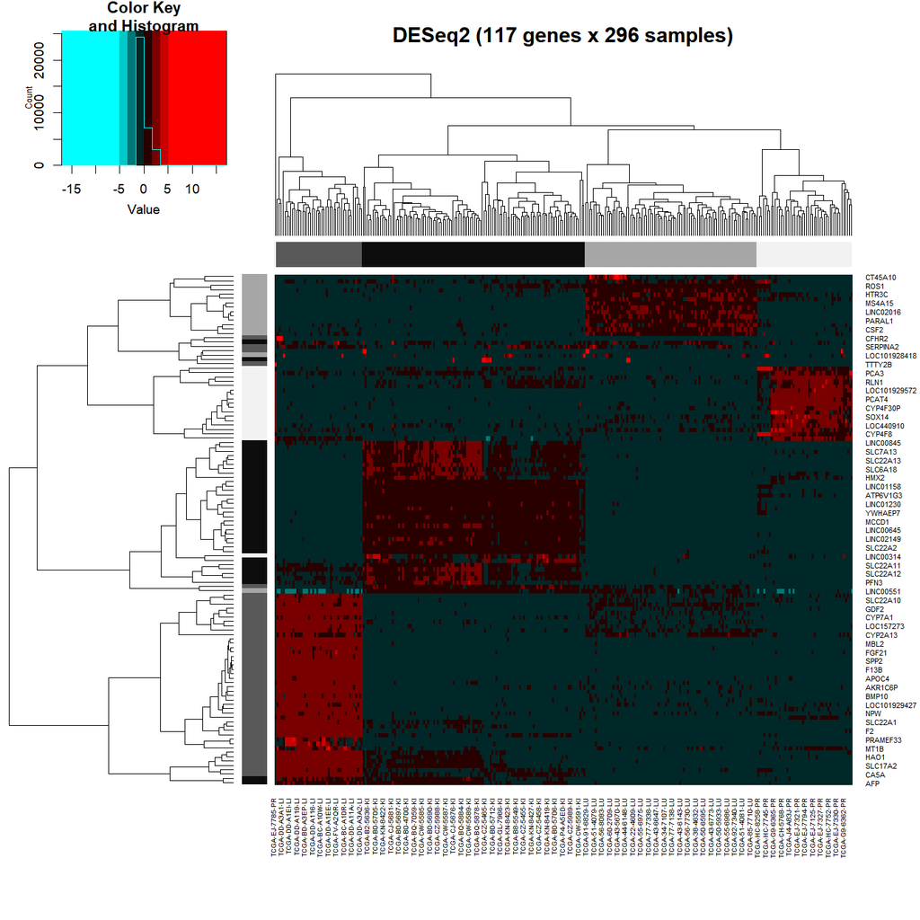

# 5 RPM vs. DESeq2

We proceed to compare both RPM and DESeq2 methods against each other in 3 key aspects: Cluster consistency, size factor correlation and raw value transformation.

## 5.1 Cluster consistency

```
#>
#>        deseq2A deseq2B deseq2C deseq2D
#>   rpmA      20       0       0       0
#>   rpmB       0      35       0       0
#>   rpmC       1       0      44       0
#>   rpmD       0       0       0      17
```

## 5.2 Size factor correlation

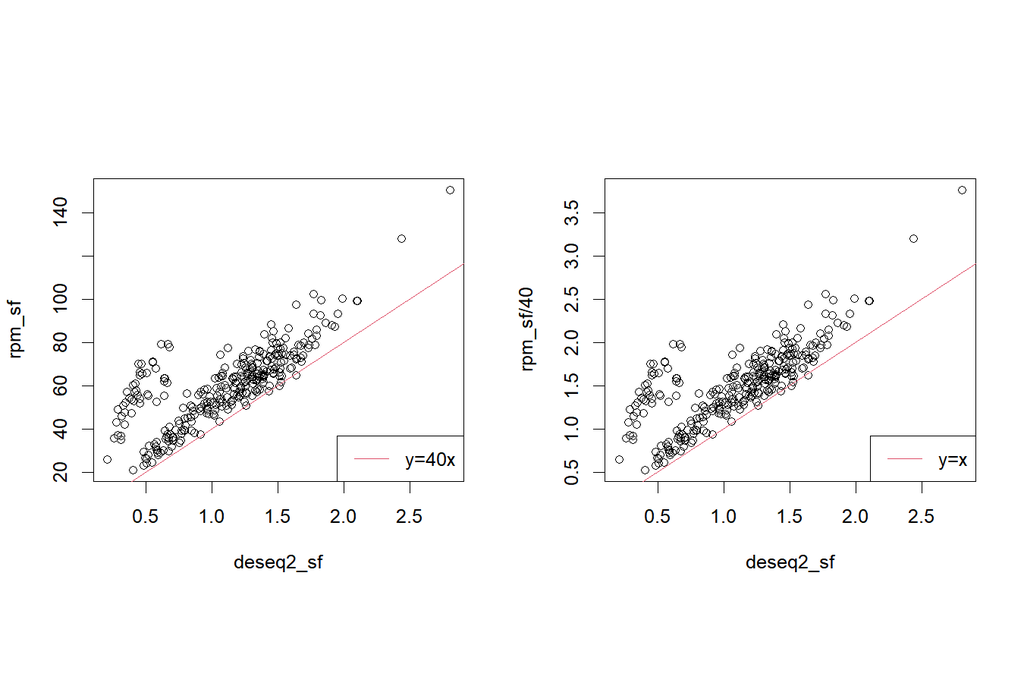

In this plot, a separation into two main groups is first noticed. Two groups whose values increase at different rates but are positively correlated similar to size factor correlation in the LIHC study.

## 5.3 Raw value transformation

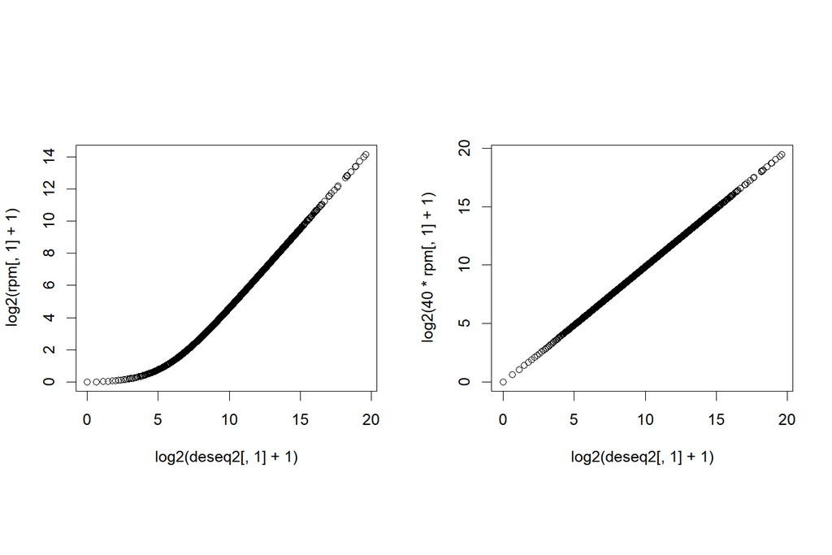

Finally, we can note that, when it comes to small raw values, the RPM method maintains the “crushing” effect even in the positive control. [This supports the argument that the crushing effect is inherent to RPM. (?)].

# 6 RPM40

RPM40 counts are obtained by dividing the RPM40 size factors* by 40. This is in order to correct for standard RPM’s small-value “crushing” effect.

```r
rpm40_sf = rpm_sf/40
rpm40 = t(t(raw_counts)/rpm40_sf)
rpm40[1:6, 1:4]
```

[output not shown]

## 6.1 Heatmap

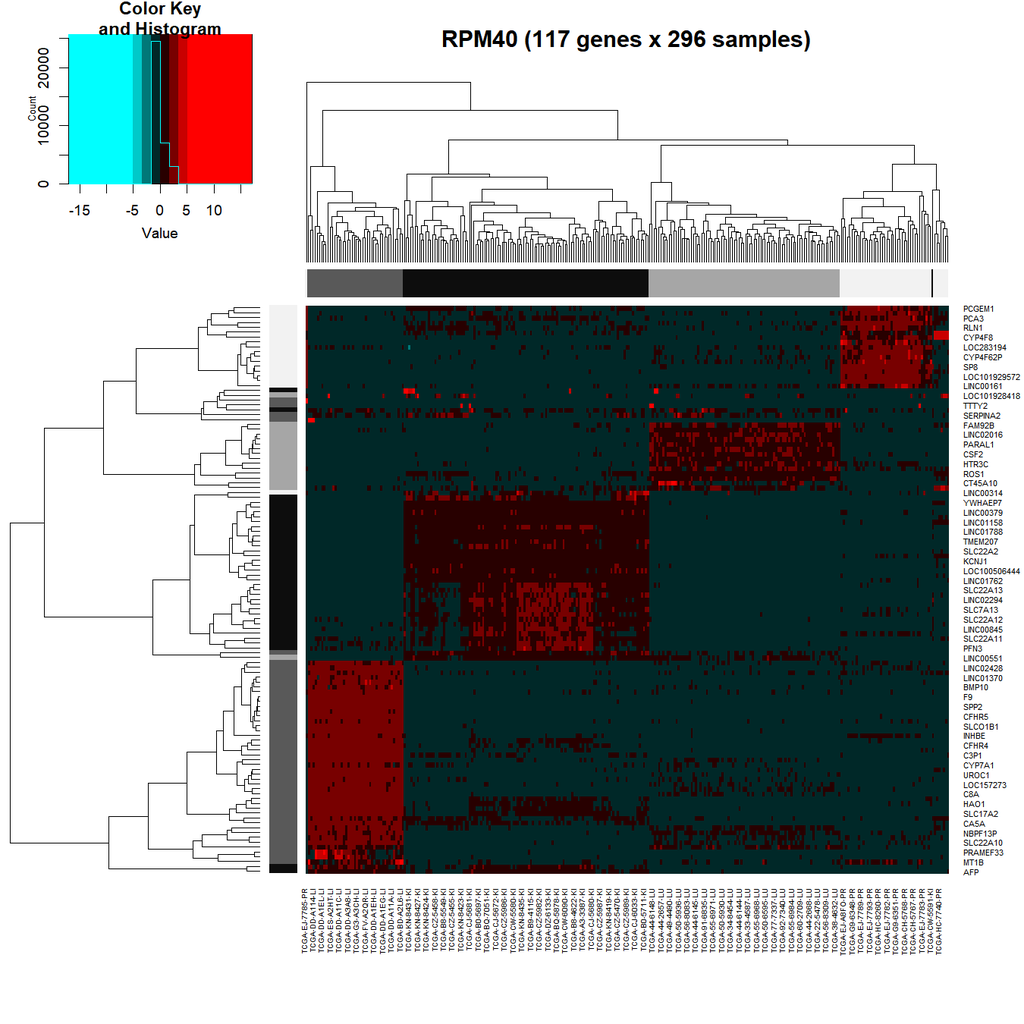

# 7 RPM40 vs. DESeq2

## 7.1 Clustering consistency table

```
#>
#>          deseq2A deseq2B deseq2C deseq2D
#>   rpm40A      14       0       0       0
#>   rpm40B       0      35       0       0
#>   rpm40C       7       0       0      17
#>   rpm40D       0       0      44       0
```

# 8 EdgeR

EdgeR is a more robust method that competes with DESeq2. EdgeR uses a TMM method to normalize counts (Trimmed Mean of M-values) and accounts for the same biases as DESeq2 such as library composition, sequencing depth and PCR affinity / RNA composition.TMM is a method that calculates size factors by first selecting a reference sample then calculating pseudo size factors using the log of the reference_sample over current sample ratio, and finally trimming the most extreme ratios and most influential genes. This way, EdgeR only takes into account differentially expressed genes and ignores the high influence of tissue-specific genes to focus normalization around housekeeping genes.

## 8.1 Scaling factors

```r
edger_sf = edgeR::calcNormFactors(raw_counts, method="TMM")
edger = t(t(raw_counts)*edger_sf)
```

## 8.2 Heatmap

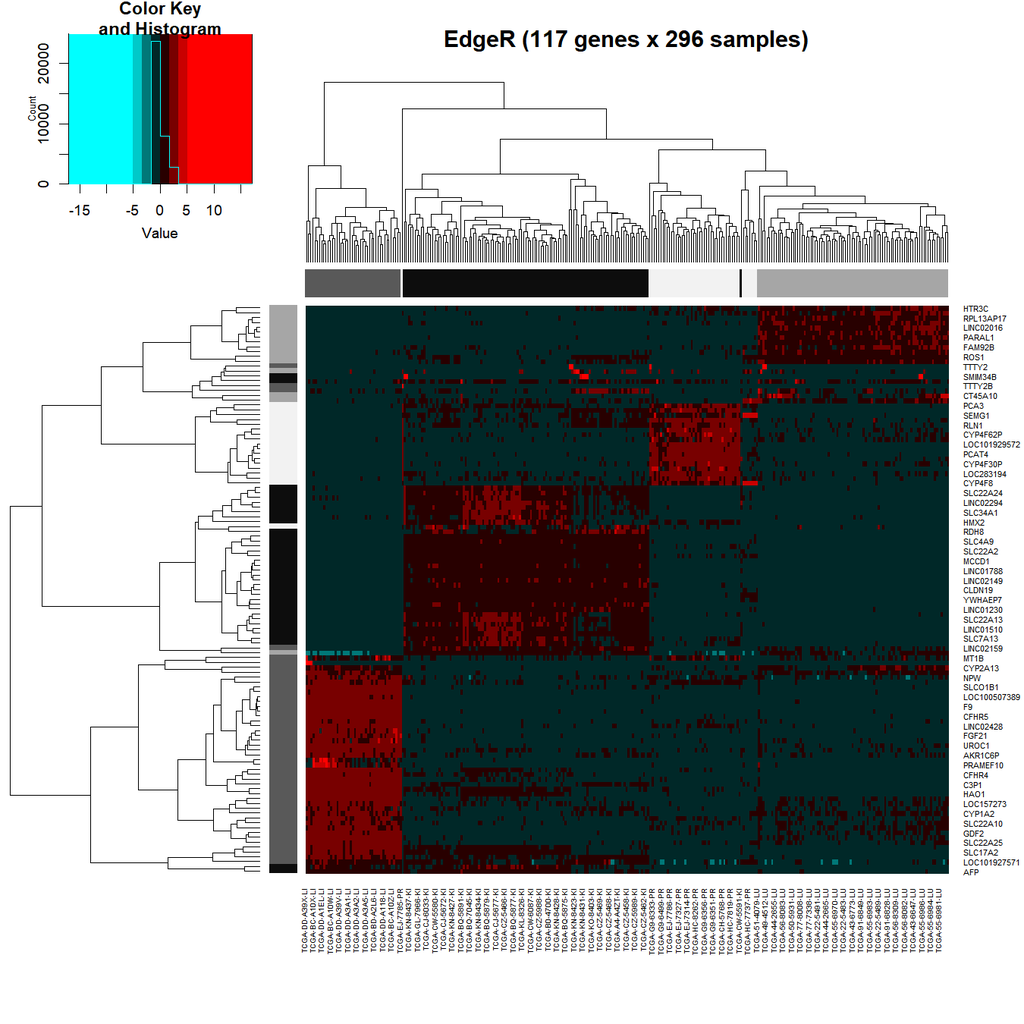

```r
data = log2(edger+1)[idx_features,]
edger_hm = dmethr::plot_expr_hm(data, colors=c("cyan", "cyan", "cyan", "black", "red", "red", "red"),
  normalization="zscore_rows",
  hcmeth_rows="cor"                ,
  csc=c("grey5", "grey35", "grey65", "grey95")[as.numeric(as.factor(substr(colnames(raw_counts), 14, 15)))],
  rsc=c("grey5", "grey35", "grey65", "grey95")[as.numeric(as.factor(features[rownames(data)]))],
  main = "EdgeR")
```

# 9 Comparison

## 9.1 Scaling factors ratio corr plot

[output not shown]

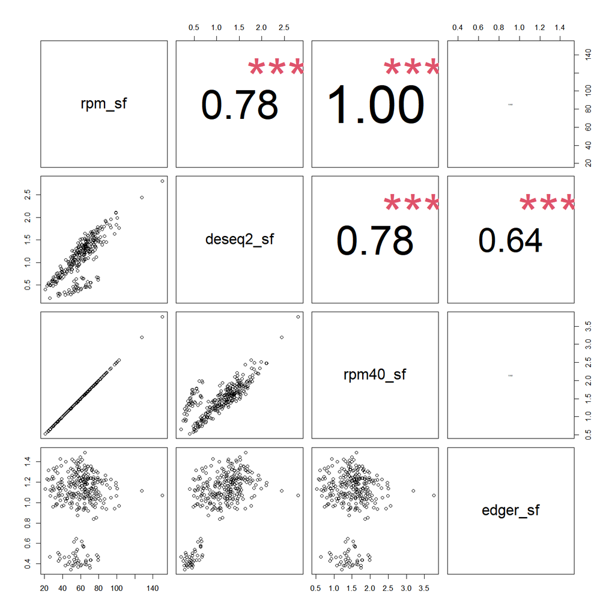

## 9.2 Raw count transformation corr plot (Sample 1)

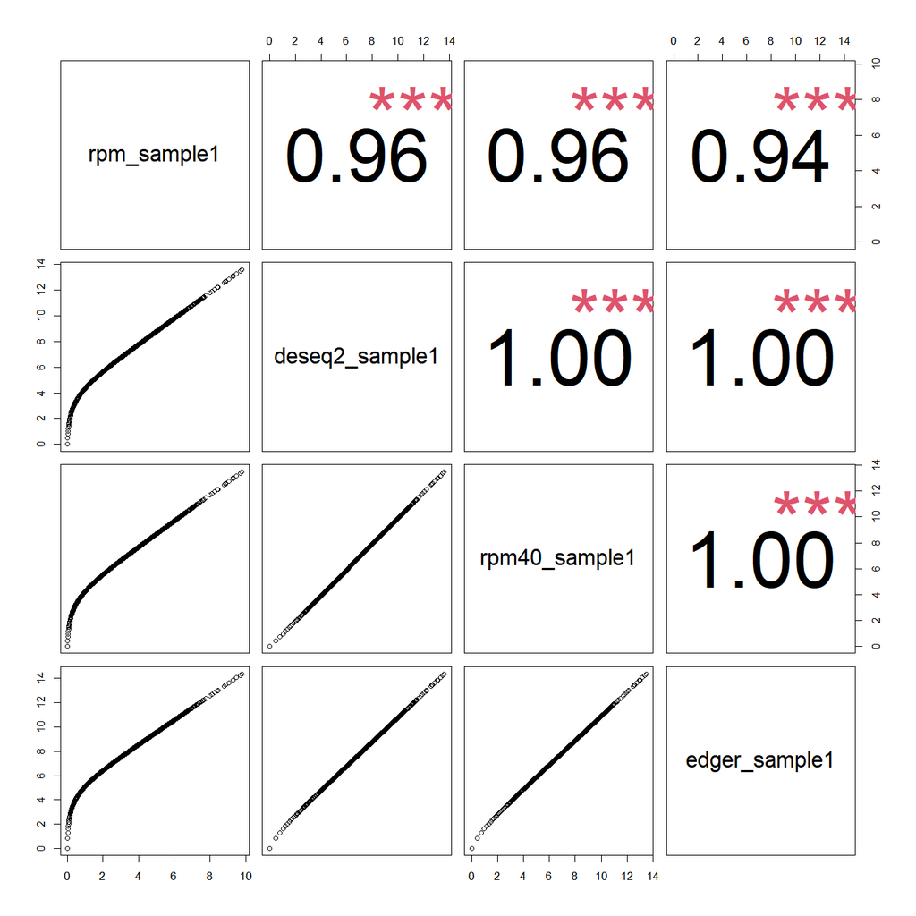

The small-value “crushing” effect is observed in all comparisons with RPM, with it being the highest when compared to EdgeR.

## 9.3 Clustering

```
#>
#>           edgerA edgerB edgerC edgerD
#>   deseq2A     20      0      0      1
#>   deseq2B      0     35      0      0
#>   deseq2C      0      0      6     38
#>   deseq2D     17      0      0      0
#>
#>        edgerA edgerB edgerC edgerD
#>   rpmA     20      0      0      0
#>   rpmB      0     35      0      0
#>   rpmC      0      0      6     39
#>   rpmD     17      0      0      0
#>
#>          edgerA edgerB edgerC edgerD
#>   rpm40A     14      0      0      0
#>   rpm40B      0     35      0      0
#>   rpm40C     23      0      0      1
#>   rpm40D      0      0      6     38
```

RPM vs DESeq2

|  | deseq2A | deseq2B | deseq2C | deseq2D |
| --- | --- | --- | --- | --- |
| rpmA | 20 | 0 | 0 | 0 |
| rpmB | 0 | 35 | 0 | 0 |
| rpmC | 1 | 0 | 44 | 0 |
| rpmD | 0 | 0 | 0 | 17 |

RPM vs EdgeR

|  | edgerA | edgerB | edgerC | edgerD |
| --- | --- | --- | --- | --- |
| rpmA | 20 | 0 | 0 | 0 |
| rpmB | 0 | 35 | 0 | 0 |
| rpmC | 0 | 0 | 6 | 39 |
| rpmD | 17 | 0 | 0 | 0 |

EdgeR VS DESeq2

|  | deseq2A | deseq2B | deseq2C | deseq2D |
| --- | --- | --- | --- | --- |
| edgerA | 20 | 0 | 0 | 17 |
| edgerB | 0 | 35 | 0 | 0 |
| edgerC | 0 | 0 | 6 | 0 |
| edgerD | 1 | 0 | 38 | 0 |

RPM40 vs DESeq2

|  | deseq2A | deseq2B | deseq2C | deseq2D |
| --- | --- | --- | --- | --- |
| rpm40A | 14 | 0 | 0 | 0 |
| rpm40B | 0 | 35 | 0 | 0 |
| rpm40C | 7 | 0 | 0 | 17 |
| rpm40D | 0 | 0 | 44 | 0 |

RPM40 vs EdgeR

[output not shown]

## 9.4 Comparing patient clusters

[output not shown]

[output not shown]

[output not shown]

[output not shown]

- How to conclude?
- Possible to compute **mutual information** or **enthropy** between cluster.
- Possible to compute survival of each groups cluster.